# Graphing Rational Functions

6/27/2018

Graphing Rational Functions by Kory Illenye

## Rational Expressions and Functions

**Blitzer definitions:**

A **Rational Expression** consists of a polynomial divided by a nonzero polynomial (denominator cannot be equal to 0).

A **Rational Function** is a function defined by a formula that is a rational expression. For Example:

\[ f(x) = \frac{x+3}{x+6}\]

## Domain of Rational Functions

The domain of a rational function is all real numbers except those that make the denominator equal to zero.

Example: \[f(x) = \frac{x + 3}{x^2-9}\] Set the denominator equal to zero and solve. \[x^2 -9 = 0\] Using the square root property we know that \(x =\pm 3\) solves this equation. So \(\pm 3\) is not in the domain.

Interval notation: \(D = (-\infty,-3)\cup(-3,3)\cup(3,\infty)\)

## Vertical Asymptotes and holes

A **vertical asymptote** is a vertical line that the graph of a function approaches, but does not touch.

Any value that would make the denominator equal to zero is either a hole or a vertical asymptote.

Lets look at our previous function: \[f(x) = \frac{x + 3}{(x+3)(x-3)}\] at \(x = 3\) we have a vertical asymptote and at \(x=-3\) we have a hole. Why? can you figure it out?

## Horizontal Asymptotes

a **horizontal asymptote** is a horizontal line that the graph of a function approaches as \(x\) gets very large or very small. The graph of a function may touch/cross its horizontal asymptote in multiple places.

lets define a general rational function: \[f(x) = \frac{a_mx^m + a_{m-1}x^{m-1}+a_{m-2}x^{m-2}+...+a_0}{b_nx^n + b_{n-1}x^{n-1}+b_{n-2}x^{n-2}+...+b_0}\] \(m\) represents the degree of the polynomial in the numerator and \(n\) denotes the degree of the polynomial in the denominator.

\(a\) represents the coefficients of the polynomial in numerator and \(b\) denotes the coefficients of the polynomial in the denominator.

## Horizontal Asymptote (continued)

- if \(m < n\) then there is a horizontal asymptote at \(y=0\).
- if \(m = n\) then there is a horizontal asymptote at \(y = \frac{a_m}{b_n}\).
- if \(m > n\) then no horizontal asymptote exists.

## Graphing a Rational Function

- step 1: factor both the numerator and denominator completely.
- step 2: state the domain.
- step 3: simplify if able.
- step 4: identify vertical asymptotes and holes.
- step 5: idtenify horizontal asymptors.
- step 6: find \(x\) and \(y\) intercepts.
- step 7: create a behavior table for points near all vertical asymptotes for both sides of the asymptote.
- step 8: plot graph

## Graphing a Rational Function Example

\[f(x) = \frac{3x+9}{x^2-9}\]

## plot

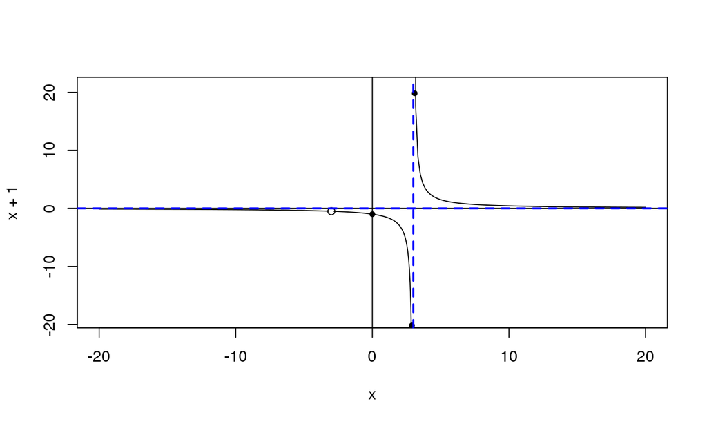

## Questions

Questions?

## References

Blitzer, Robert, *"Algebra and Trigonometry 6th edition"*, 2018.